# Twitter Analysis 2017

## Introduction

We cleaned the data by 1. changed all text into lower cases 2. removed stopwords suchs as “a”, “the”, etc. We also took “library”, “libraries”, “librarian”, “librarians” out from the text because they are our key searching words 3. removed punctuation 4. remove numbers 5. remove stem words (A **stem** is a part of word, e.g de-, -(e)d, -(e)s.)

We also calculated the sentiment score to each tweets. A positive score means positive sentiment and a negative score means negative sentiment.

## The 20 most common words for all tweets

```
##          word  freq
## book     book 11623
## new       new  6930
## get       get  5199
## read     read  4879
## school school  4664
## public public  4583
## today   today  4113
## make     make  3372
## one       one  3348
## free     free  3287
## day       day  3198
## like     like  3166
## see       see  2964
## open     open  2845
## come     come  2836
## thank   thank  2590
## work     work  2583
## look     look  2560
## love     love  2538
## year     year  2477
```

The WordCloud of the first 150 most common words for all tweets

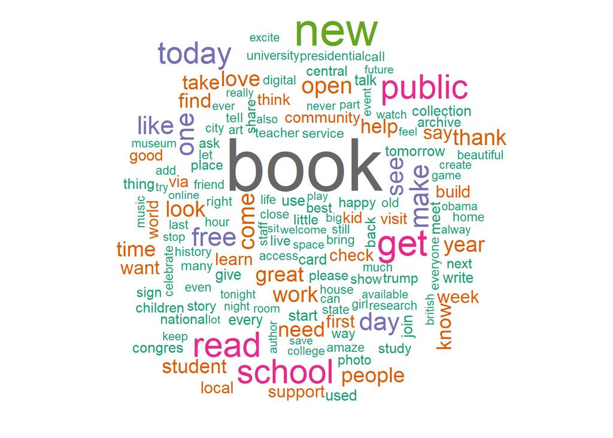

```r
cor.special <- brewer.pal(8,"Dark2")
d.1 <- d[1:150,]
wordcloud(d.1$word, d.1$freq, scale=c(5,.5),  # make a word cloud
          colors=cor.special, ordered.colors=F)
```

## Most common adjective words

We also would like to analyze the most common adjectives in the tweets to see if we can have a better understanding of people’s attitudes to libraries.

The 20 most common adjective words

```
##             word freq
## 137          new 6930
## 74          free 3287
## 144         open 2845
## 87         great 2423
## 72         first 1894
## 115        local 1602
## 83          good 1499
## 138         next 1243
## 113       little 1220
## 135     national 1216
## 25       central 1207
## 89         happy 1181
## 114         live 1168
## 143          old 1063
## 122         many 1040
## 174        right 1015
## 158 presidential  978
## 45       digital  977
## 109         last  929
## 17     beautiful  873
```

The Word Cloud of the 150 most common adjective words

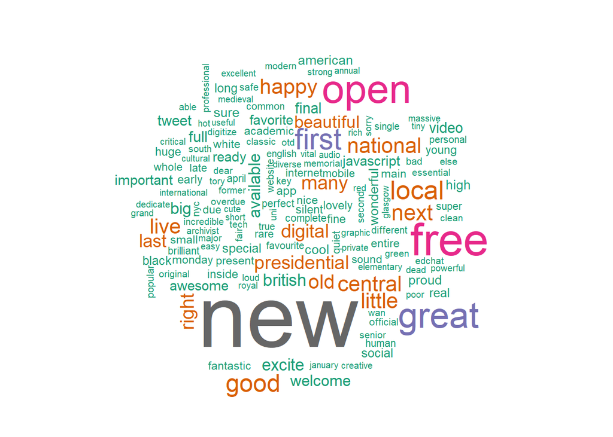

```r
cor.special <- brewer.pal(8,"Dark2")
adj.cloud <- adj.all[1:150,]
wordcloud(adj.cloud$word, adj.cloud$freq, scale=c(6,.5),  # make a word cloud
          colors=cor.special, ordered.colors=F)
```

## Positive vs Negative

We estimated the sentiment of each tweets and score them. A positive sentiment_polarity means the tweet is a positive one. A negative_polarity means the tweet is a negative one. We classified the tweets into positive and negative, and analyzed both positive and negative tweets below.

### Analysis 1: LASSO

Use LASSO to analyze the relationship between each word and sentiment of people.

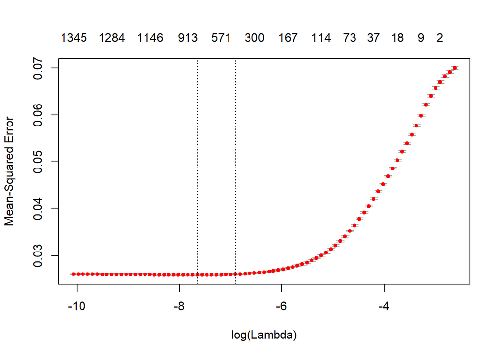

Prediction Error is small (0.026), so the model is acceptable.

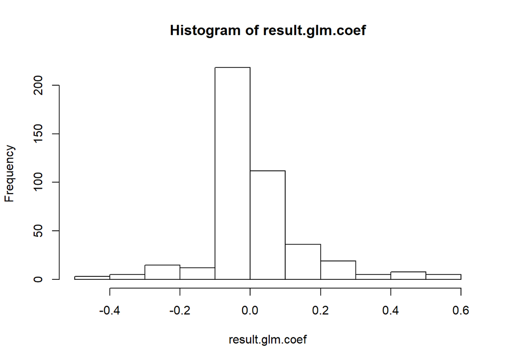

#### Postive word cloud

Extract words with postitive coefficients (words that have positive corelations to sentiments) The following words are 20 words with most positive coef’s.

```
##   greatest    awesome    perfect  excellent       best  wonderful
##     0.5241     0.5209     0.5078     0.5019     0.5009     0.4793
##  beautiful incredible        lol  brilliant      happy        win
##     0.4732     0.4414     0.4368     0.4322     0.4141     0.4086
##      great    welcome      proud       fair       good        joy
##     0.4069     0.3947     0.3788     0.3498     0.3169     0.3138
##    popular       kind
##     0.2924     0.2819
```

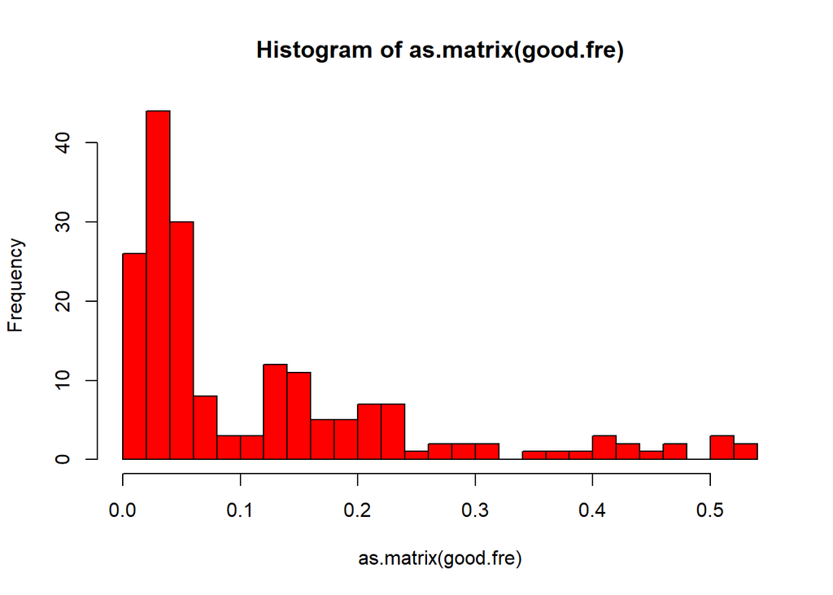

Below is the wordcloud of all the ppositive words from all 2017 tweets. The larger the word is, the more positive it correlates to sentiment. People in 2017 thinks libraries are wonderful, awesome, excellent and etc.

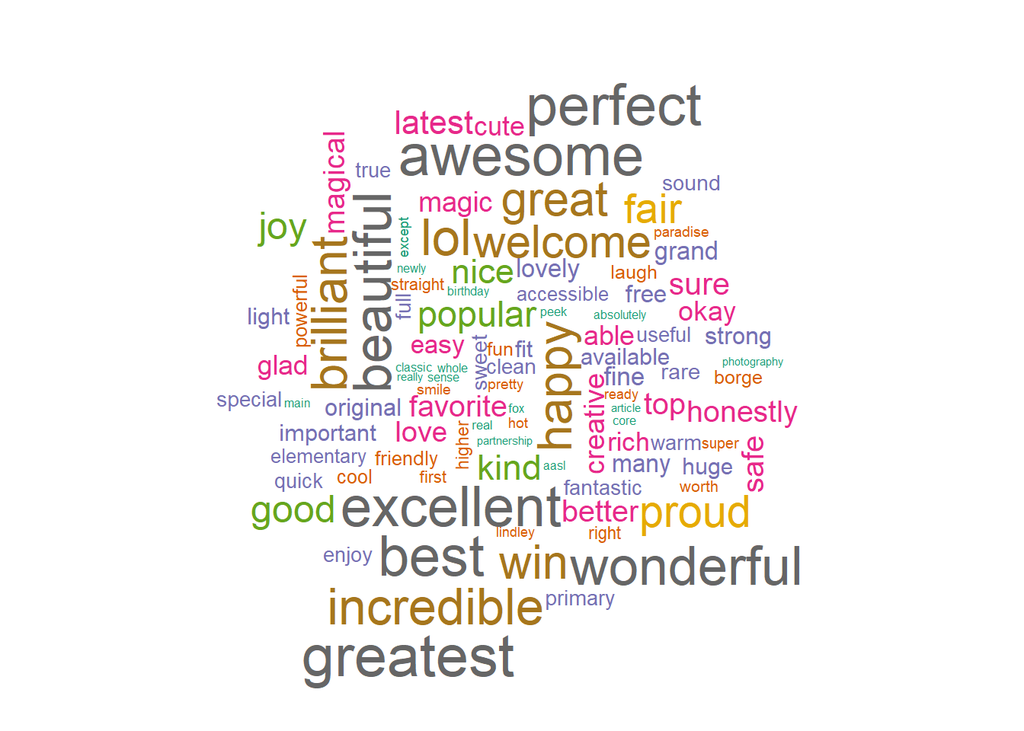

#### Negative word cloud

Similarly to the negative coef’s which is positively correlated to be a tweet with negative sentiment. The following words are 20 words with most negative coef’s.

```
##      base      hate       bad      cold     wrong     sorry     crazy
##    0.4628    0.4527    0.4242    0.3566    0.3276    0.3222    0.3158
##       sad    secret     weird    random    behind      fail      fake
##    0.3149    0.2868    0.2840    0.2759    0.2730    0.2640    0.2625
##      game      poor      fuck seriously      hard      mean
##    0.2462    0.2388    0.2357    0.2262    0.2151    0.2120
```

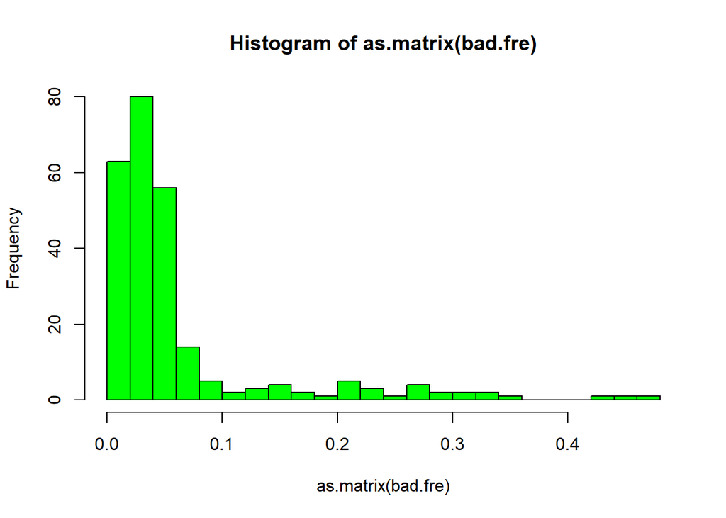

Below is the wordcloud of all the negative words from all 2017 tweets. The larger the word is, the more negative it correlates to sentiment. People in 2017 thinks libraries are bad, sad and crazy. Word “cold” could imply the air conditioning or hear in libraries are not good. “Little” and “small” may imply that people thinks libraries are small and have little books. “Behind” may implies libraries may be a little outdated. We can dig into each word and figure out how could libraries improve themselves.

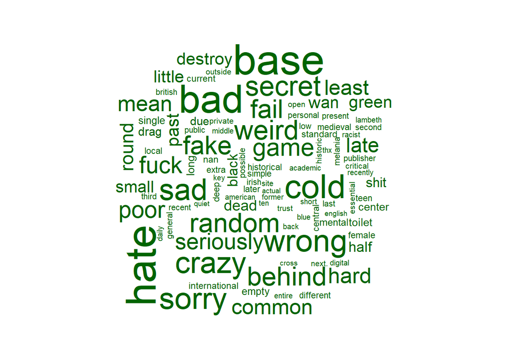

#### Put two clouds together

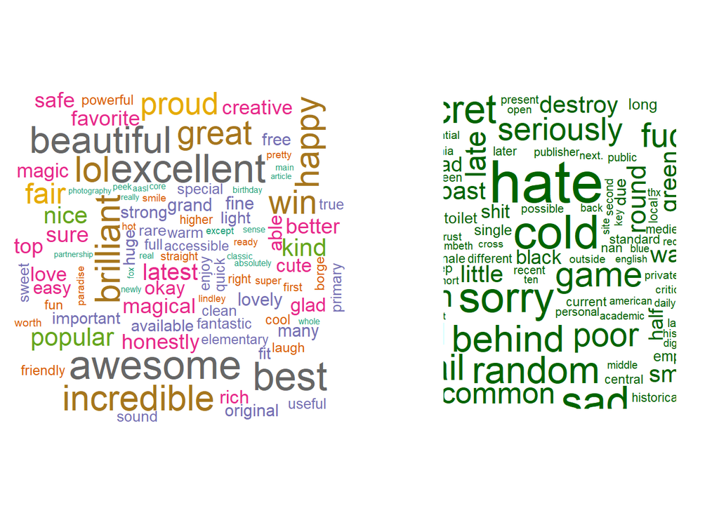

## Sentiment vs Month

Below is a graph of people’s sentiment to library during months. We see fluctuation from January to December. After statistical analysis we found all numbers are within the boundaries of inner fence (0.1064 to 0.1566). This mean the fluctuation of sentiment is just due to randomness.

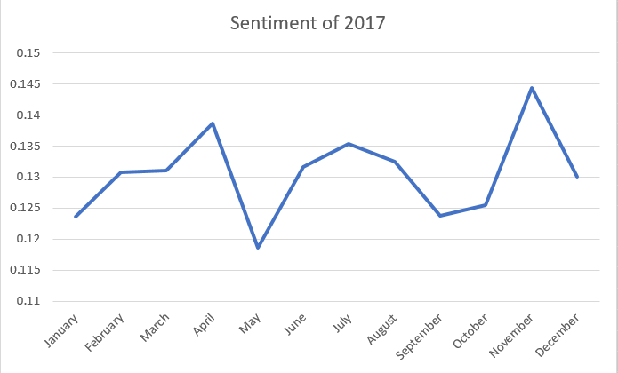

## Pie chart of percentage of sentiment

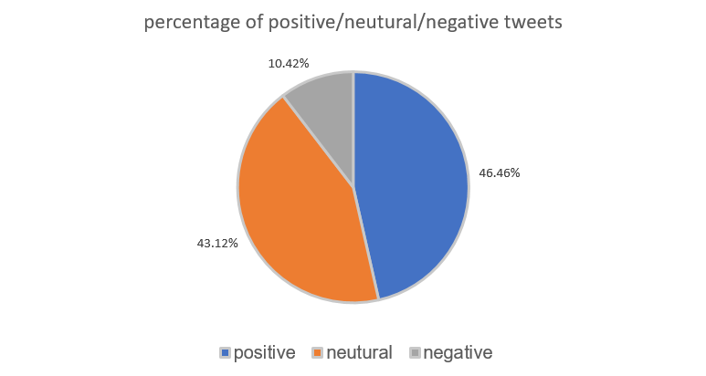